# LET0001

## Factores comunes de la personalidad

En este estudio evaluaremos la presencia de factores comunes a la personalidad de las personas utilizando un cuestionario denominado Big Five.

¿Será posible que existen dimensiones de la personalidad? para ello procederemos con un análisis exploratorio en el cual analizaremos cuantos factores o componentes en el cuestionario explican la mayor variabilidad en la respuesta, a continuación presentamos esto de manera gráfica a través de un Scree Plot:

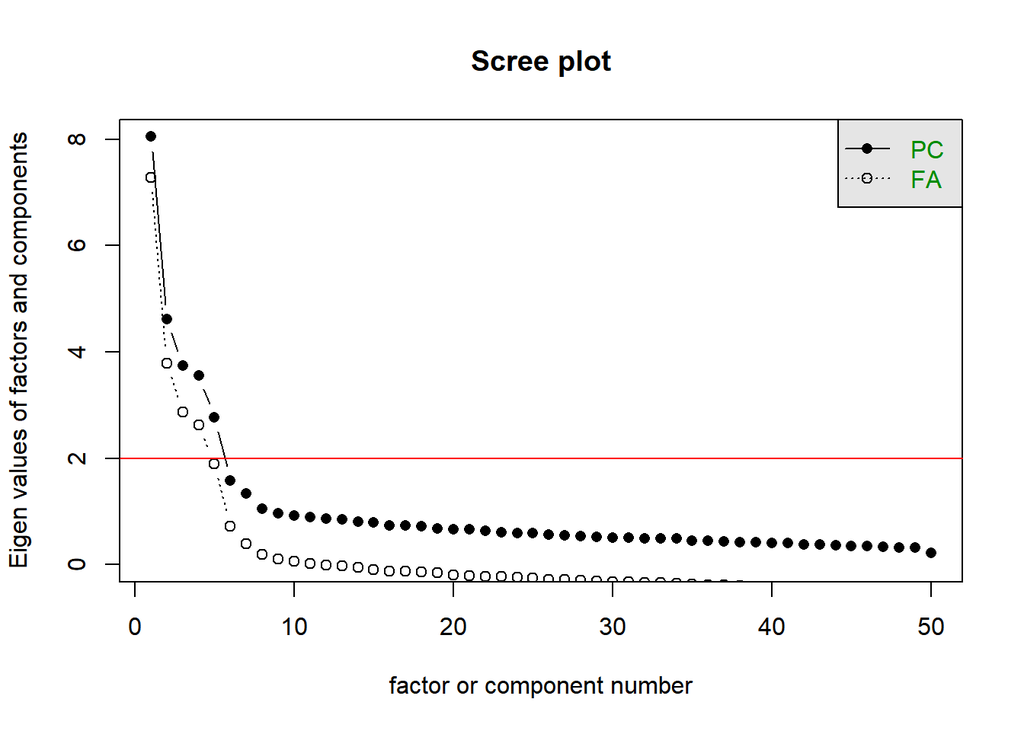

De este grafico podemos concluir que luego del quinto factor la varianza explicada comienza a ser marginal, por lo que podemos empezar a conjeturar que hay 5 dimensiones preponderantes en la personalidad de quienes responden. Esto a su vez se visualiza como un “codo” determinado por la linea roja del grafico 1.

```
##             E1         E2         E3         E4         E5         E6
## E1   1.0000000 -0.4668188  0.5280446 -0.5292856  0.5359919 -0.3911668
## E2  -0.4668188  1.0000000 -0.4951104  0.5821114 -0.5944794  0.6332581
## E3   0.5280446 -0.4951104  1.0000000 -0.5328883  0.6477784 -0.4406720
## E4  -0.5292856  0.5821114 -0.5328883  1.0000000 -0.5644882  0.5348725
## E5   0.5359919 -0.5944794  0.6477784 -0.5644882  1.0000000 -0.5382455
## E6  -0.3911668  0.6332581 -0.4406720  0.5348725 -0.5382455  1.0000000
## E7   0.6473902 -0.5331051  0.6459513 -0.5568332  0.7010917 -0.4612096
## E8  -0.4075992  0.4210507 -0.3624090  0.4982200 -0.3896354  0.3698685
## E9   0.5110577 -0.4092960  0.4740697 -0.5014569  0.4719999 -0.3802311
## E10 -0.4630488  0.5283042 -0.5428575  0.5716111 -0.6221595  0.4831600
##             E7         E8         E9        E10
## E1   0.6473902 -0.4075992  0.5110577 -0.4630488
## E2  -0.5331051  0.4210507 -0.4092960  0.5283042
## E3   0.6459513 -0.3624090  0.4740697 -0.5428575
## E4  -0.5568332  0.4982200 -0.5014569  0.5716111
## E5   0.7010917 -0.3896354  0.4719999 -0.6221595
## E6  -0.4612096  0.3698685 -0.3802311  0.4831600
## E7   1.0000000 -0.3904309  0.4937511 -0.5985732
## E8  -0.3904309  1.0000000 -0.5764021  0.4372329
## E9   0.4937511 -0.5764021  1.0000000 -0.4262641
## E10 -0.5985732  0.4372329 -0.4262641  1.0000000
```

aqui vemos la correlacion entre las respuestas a la categorpia E. mas adleante analizaremos que que podemos inferir de estas correlaciones